# CourseraPredictionAssignment

New Ru Wee

9/7/2020

Using devices such as Jawbone Up, Nike FuelBand, and Fitbit it is now possible to collect a large amount of data about personal activity relatively inexpensively. These type of devices are part of the quantified self movement – a group of enthusiasts who take measurements about themselves regularly to improve their health, to find patterns in their behavior, or because they are tech geeks. One thing that people regularly do is quantify how much of a particular activity they do, but they rarely quantify how well they do it. In this project, the goal will be to use data from accelerometers on the belt, forearm, arm, and dumbell of 6 participants. They were asked to perform barbell lifts correctly and incorrectly in 5 different ways. More information is available from the website here: http://web.archive.org/web/20161224072740/http:/groupware.les.inf.puc-rio.br/har (see the section on the Weight Lifting Exercise Dataset).

# Loading Dataset

```r
library(caret)
```

```r
set.seed(123)

train <- read.csv(url("https://d396qusza40orc.cloudfront.net/predmachlearn/pml-training.csv"), na.strings=c("NA","","#DIV/0!"))
train <- train[, colSums(is.na(train)) == 0]
# View(train)
# dim(train)
names(train)
```

```
##  [1] "X"                    "user_name"            "raw_timestamp_part_1"
##  [4] "raw_timestamp_part_2" "cvtd_timestamp"       "new_window"
##  [7] "num_window"           "roll_belt"            "pitch_belt"
## [10] "yaw_belt"             "total_accel_belt"     "gyros_belt_x"
## [13] "gyros_belt_y"         "gyros_belt_z"         "accel_belt_x"
## [16] "accel_belt_y"         "accel_belt_z"         "magnet_belt_x"
## [19] "magnet_belt_y"        "magnet_belt_z"        "roll_arm"
## [22] "pitch_arm"            "yaw_arm"              "total_accel_arm"
## [25] "gyros_arm_x"          "gyros_arm_y"          "gyros_arm_z"
## [28] "accel_arm_x"          "accel_arm_y"          "accel_arm_z"
## [31] "magnet_arm_x"         "magnet_arm_y"         "magnet_arm_z"
## [34] "roll_dumbbell"        "pitch_dumbbell"       "yaw_dumbbell"
## [37] "total_accel_dumbbell" "gyros_dumbbell_x"     "gyros_dumbbell_y"
## [40] "gyros_dumbbell_z"     "accel_dumbbell_x"     "accel_dumbbell_y"
## [43] "accel_dumbbell_z"     "magnet_dumbbell_x"    "magnet_dumbbell_y"
## [46] "magnet_dumbbell_z"    "roll_forearm"         "pitch_forearm"
## [49] "yaw_forearm"          "total_accel_forearm"  "gyros_forearm_x"
## [52] "gyros_forearm_y"      "gyros_forearm_z"      "accel_forearm_x"
## [55] "accel_forearm_y"      "accel_forearm_z"      "magnet_forearm_x"
## [58] "magnet_forearm_y"     "magnet_forearm_z"     "classe"
```

```r
validation <- read.csv(url("https://d396qusza40orc.cloudfront.net/predmachlearn/pml-testing.csv"), na.strings=c("NA","","#DIV/0!"))
validation <- validation[, colSums(is.na(validation))==0]
# View(test)
# dim(test)

splitIndex  <- createDataPartition(train$classe, p=0.7, list=FALSE)
train_set <- train[ splitIndex, ]
test_set  <- train[-splitIndex, ]
```

# EDA

```r
library(skimr)
skimmed <- skim(train_set)
skimmed
```

Data summary

| Name | train_set |
| --- | --- |
| Number of rows | 13737 |
| Number of columns | 60 |
| _______________________ |  |
| Column type frequency: |  |
| character | 4 |
| numeric | 56 |
| ________________________ |  |
| Group variables | None |

**Variable type: character**

| skim_variable | n_missing | complete_rate | min | max | empty | n_unique | whitespace |
| --- | --- | --- | --- | --- | --- | --- | --- |
| user_name | 0 | 1 | 5 | 8 | 0 | 6 | 0 |
| cvtd_timestamp | 0 | 1 | 16 | 16 | 0 | 20 | 0 |
| new_window | 0 | 1 | 2 | 3 | 0 | 2 | 0 |
| classe | 0 | 1 | 1 | 1 | 0 | 5 | 0 |

**Variable type: numeric**

| skim_variable | n_missing | complete_rate | mean | sd | p0 | p25 | p50 | p75 | p100 | hist |
| --- | --- | --- | --- | --- | --- | --- | --- | --- | --- | --- |
| X | 0 | 1 | 9807.25 | 5671.25 | 1.00000e+00 | 4878.00 | 9828.00 | 14722.00 | 1.962200e+04 | ▇▇▇▇▇ |
| raw_timestamp_part_1 | 0 | 1 | 1322829610.97 | 205291.80 | 1.32249e+09 | 1322673102.00 | 1322832926.00 | 1323084267.00 | 1.323095e+09 | ▃▃▇▁▆ |
| raw_timestamp_part_2 | 0 | 1 | 500079.20 | 288601.56 | 2.94000e+02 | 252422.00 | 496393.00 | 748421.00 | 9.988010e+05 | ▇▇▇▇▇ |
| num_window | 0 | 1 | 430.23 | 248.30 | 1.00000e+00 | 221.00 | 422.00 | 645.00 | 8.640000e+02 | ▇▇▇▇▇ |
| roll_belt | 0 | 1 | 64.25 | 62.72 | -2.88000e+01 | 1.10 | 113.00 | 123.00 | 1.620000e+02 | ▇▁▁▅▅ |
| pitch_belt | 0 | 1 | 0.45 | 22.24 | -5.58000e+01 | 1.92 | 5.32 | 15.00 | 6.030000e+01 | ▃▁▇▅▁ |
| yaw_belt | 0 | 1 | -11.67 | 94.86 | -1.80000e+02 | -88.30 | -13.60 | 11.90 | 1.790000e+02 | ▁▇▅▁▃ |
| total_accel_belt | 0 | 1 | 11.29 | 7.75 | 0.00000e+00 | 3.00 | 17.00 | 18.00 | 2.900000e+01 | ▇▁▂▆▁ |
| gyros_belt_x | 0 | 1 | -0.01 | 0.21 | -1.04000e+00 | -0.03 | 0.03 | 0.11 | 2.200000e+00 | ▁▇▁▁▁ |
| gyros_belt_y | 0 | 1 | 0.04 | 0.08 | -6.40000e-01 | 0.00 | 0.02 | 0.11 | 6.100000e-01 | ▁▁▇▃▁ |
| gyros_belt_z | 0 | 1 | -0.13 | 0.24 | -1.46000e+00 | -0.20 | -0.10 | -0.02 | 1.610000e+00 | ▁▂▇▁▁ |
| accel_belt_x | 0 | 1 | -5.79 | 29.47 | -1.20000e+02 | -21.00 | -15.00 | -5.00 | 8.500000e+01 | ▁▁▇▁▂ |
| accel_belt_y | 0 | 1 | 30.10 | 28.63 | -6.90000e+01 | 3.00 | 33.00 | 61.00 | 1.640000e+02 | ▁▇▇▁▁ |
| accel_belt_z | 0 | 1 | -72.38 | 100.40 | -2.75000e+02 | -162.00 | -152.00 | 27.00 | 1.050000e+02 | ▁▇▁▅▃ |
| magnet_belt_x | 0 | 1 | 55.00 | 63.93 | -5.20000e+01 | 8.00 | 34.00 | 58.00 | 4.850000e+02 | ▇▁▂▁▁ |
| magnet_belt_y | 0 | 1 | 593.76 | 35.35 | 3.54000e+02 | 581.00 | 601.00 | 610.00 | 6.730000e+02 | ▁▁▁▇▃ |
| magnet_belt_z | 0 | 1 | -345.41 | 64.17 | -6.21000e+02 | -375.00 | -319.00 | -306.00 | 2.870000e+02 | ▁▇▁▁▁ |
| roll_arm | 0 | 1 | 17.78 | 73.20 | -1.78000e+02 | -32.20 | 0.00 | 77.50 | 1.800000e+02 | ▁▃▇▆▂ |
| pitch_arm | 0 | 1 | -4.46 | 30.72 | -8.82000e+01 | -26.00 | 0.00 | 11.50 | 8.850000e+01 | ▁▅▇▂▁ |
| yaw_arm | 0 | 1 | -0.52 | 71.61 | -1.80000e+02 | -43.10 | 0.00 | 46.70 | 1.800000e+02 | ▁▃▇▃▂ |
| total_accel_arm | 0 | 1 | 25.53 | 10.45 | 1.00000e+00 | 17.00 | 27.00 | 33.00 | 6.500000e+01 | ▃▆▇▁▁ |
| gyros_arm_x | 0 | 1 | 0.02 | 2.00 | -6.37000e+00 | -1.36 | 0.06 | 1.53 | 4.870000e+00 | ▁▃▇▆▂ |
| gyros_arm_y | 0 | 1 | -0.25 | 0.86 | -3.44000e+00 | -0.79 | -0.24 | 0.16 | 2.810000e+00 | ▁▂▇▂▁ |
| gyros_arm_z | 0 | 1 | 0.27 | 0.55 | -2.33000e+00 | -0.08 | 0.23 | 0.72 | 2.660000e+00 | ▁▂▇▃▁ |
| accel_arm_x | 0 | 1 | -60.05 | 182.68 | -4.04000e+02 | -241.00 | -46.00 | 84.00 | 4.350000e+02 | ▇▆▇▅▁ |
| accel_arm_y | 0 | 1 | 32.61 | 109.66 | -3.18000e+02 | -54.00 | 14.00 | 139.00 | 3.080000e+02 | ▁▃▇▇▂ |
| accel_arm_z | 0 | 1 | -70.84 | 133.98 | -6.30000e+02 | -142.00 | -48.00 | 23.00 | 2.920000e+02 | ▁▁▅▇▁ |
| magnet_arm_x | 0 | 1 | 192.20 | 444.52 | -5.84000e+02 | -301.00 | 290.00 | 640.00 | 7.820000e+02 | ▆▃▂▃▇ |
| magnet_arm_y | 0 | 1 | 155.96 | 201.65 | -3.92000e+02 | -8.00 | 200.00 | 322.00 | 5.830000e+02 | ▁▃▅▇▂ |
| magnet_arm_z | 0 | 1 | 307.10 | 325.84 | -5.97000e+02 | 129.00 | 445.00 | 546.00 | 6.940000e+02 | ▁▂▂▃▇ |
| roll_dumbbell | 0 | 1 | 23.56 | 70.25 | -1.53710e+02 | -19.94 | 48.07 | 67.78 | 1.535500e+02 | ▂▂▃▇▂ |
| pitch_dumbbell | 0 | 1 | -10.84 | 37.03 | -1.49590e+02 | -40.96 | -20.85 | 17.35 | 1.494000e+02 | ▁▆▇▂▁ |
| yaw_dumbbell | 0 | 1 | 2.07 | 82.36 | -1.50870e+02 | -77.57 | 0.00 | 79.97 | 1.549500e+02 | ▃▇▅▅▆ |
| total_accel_dumbbell | 0 | 1 | 13.65 | 10.24 | 0.00000e+00 | 4.00 | 10.00 | 19.00 | 5.800000e+01 | ▇▅▃▁▁ |
| gyros_dumbbell_x | 0 | 1 | 0.15 | 1.78 | -2.04000e+02 | -0.03 | 0.13 | 0.35 | 2.200000e+00 | ▁▁▁▁▇ |
| gyros_dumbbell_y | 0 | 1 | 0.05 | 0.66 | -2.10000e+00 | -0.14 | 0.03 | 0.21 | 5.200000e+01 | ▇▁▁▁▁ |
| gyros_dumbbell_z | 0 | 1 | -0.12 | 2.72 | -2.38000e+00 | -0.31 | -0.13 | 0.03 | 3.170000e+02 | ▇▁▁▁▁ |
| accel_dumbbell_x | 0 | 1 | -28.43 | 67.35 | -4.19000e+02 | -50.00 | -8.00 | 10.00 | 2.350000e+02 | ▁▁▆▇▁ |
| accel_dumbbell_y | 0 | 1 | 51.96 | 80.82 | -1.89000e+02 | -9.00 | 40.00 | 110.00 | 3.150000e+02 | ▁▇▇▅▁ |
| accel_dumbbell_z | 0 | 1 | -37.52 | 109.28 | -2.73000e+02 | -141.00 | 0.00 | 38.00 | 3.180000e+02 | ▃▃▇▂▁ |
| magnet_dumbbell_x | 0 | 1 | -328.71 | 340.26 | -6.43000e+02 | -535.00 | -480.00 | -307.00 | 5.840000e+02 | ▇▂▁▁▂ |
| magnet_dumbbell_y | 0 | 1 | 219.91 | 328.00 | -3.60000e+03 | 231.00 | 310.00 | 390.00 | 6.330000e+02 | ▁▁▁▁▇ |
| magnet_dumbbell_z | 0 | 1 | 45.00 | 139.39 | -2.62000e+02 | -46.00 | 12.00 | 95.00 | 4.520000e+02 | ▁▇▆▂▂ |
| roll_forearm | 0 | 1 | 33.19 | 108.26 | -1.80000e+02 | -2.44 | 20.60 | 140.00 | 1.800000e+02 | ▃▂▇▂▇ |
| pitch_forearm | 0 | 1 | 10.77 | 28.42 | -7.25000e+01 | 0.00 | 9.60 | 28.90 | 8.980000e+01 | ▁▁▇▃▁ |
| yaw_forearm | 0 | 1 | 19.03 | 103.90 | -1.80000e+02 | -70.50 | 0.00 | 111.00 | 1.800000e+02 | ▅▅▇▆▇ |
| total_accel_forearm | 0 | 1 | 34.72 | 10.08 | 0.00000e+00 | 29.00 | 36.00 | 41.00 | 1.080000e+02 | ▁▇▂▁▁ |
| gyros_forearm_x | 0 | 1 | 0.16 | 0.66 | -2.20000e+01 | -0.22 | 0.05 | 0.56 | 3.520000e+00 | ▁▁▁▁▇ |
| gyros_forearm_y | 0 | 1 | 0.09 | 3.43 | -7.02000e+00 | -1.46 | 0.03 | 1.64 | 3.110000e+02 | ▇▁▁▁▁ |
| gyros_forearm_z | 0 | 1 | 0.16 | 2.06 | -5.55000e+00 | -0.18 | 0.08 | 0.49 | 2.310000e+02 | ▇▁▁▁▁ |
| accel_forearm_x | 0 | 1 | -62.46 | 180.51 | -4.96000e+02 | -179.00 | -57.00 | 75.00 | 4.770000e+02 | ▂▆▇▅▁ |
| accel_forearm_y | 0 | 1 | 163.12 | 200.28 | -5.95000e+02 | 55.00 | 201.00 | 312.00 | 9.230000e+02 | ▁▃▇▃▁ |
| accel_forearm_z | 0 | 1 | -56.51 | 138.45 | -4.46000e+02 | -182.00 | -41.00 | 26.00 | 2.870000e+02 | ▁▇▅▅▃ |
| magnet_forearm_x | 0 | 1 | -314.03 | 346.44 | -1.28000e+03 | -617.00 | -381.00 | -77.00 | 6.720000e+02 | ▁▇▆▅▁ |
| magnet_forearm_y | 0 | 1 | 377.48 | 507.68 | -8.92000e+02 | 4.00 | 586.00 | 735.00 | 1.480000e+03 | ▂▂▂▇▁ |
| magnet_forearm_z | 0 | 1 | 391.60 | 368.89 | -9.66000e+02 | 186.00 | 509.00 | 651.00 | 1.070000e+03 | ▁▁▃▇▃ |

# Removing the first 6 columns

```r
train_set <- train_set[, -(1:6)]
test_set  <- test_set[, -(1:6)]
dim(train_set)
```

```
## [1] 13737    54
```

```r
# dim(test_set)
```

# Finding highly correlated features

```r
set.seed(7)
# calculate correlation matrix
correlationMatrix <- cor(train_set[,-54])
# summarize the correlation matrix
print(correlationMatrix)
```

[output not shown]

[output cut: 809 more lines]

[output not shown]

```r
# find attributes that are highly corrected (ideally >0.75)
highlyCorrelated <- findCorrelation(correlationMatrix, cutoff=0.5)
# print indexes of highly correlated attributes
print(highlyCorrelated)
```

```
##  [1] 11  2 10 23  5  4 37  9  3 12 30 38 36 39 48 31 22 35 40 53 24 26 14 49 27
## [26] 16 33 47 32 34 19
```

# Building classification Model

```r
control <- trainControl(method="cv", number=10)
metric <- "Accuracy"


set.seed(7)
fit.lda <- train(classe~., data=train_set, method="lda", metric=metric,trControl=control)

# CART
set.seed(7)
fit.cart <- train(classe~., data=train_set, method="rpart", metric=metric, trControl=control)
# kNN
set.seed(7)
fit.knn <- train(classe~., data=train_set, method="knn", metric=metric, trControl=control)

# SVM
set.seed(7)
fit.svm <- train(classe~., data=train_set, method="svmRadial", metric=metric, trControl=control)
# Random Forest
set.seed(7)
fit.rf <- train(classe~., data=train_set, method="rf", metric=metric, trControl=control)
```

# Comparing results between models

```r
results <- resamples(list(lda=fit.lda, cart=fit.cart, knn=fit.knn, svm=fit.svm, rf=fit.rf))
summary(results)
```

```
##
## Call:
## summary.resamples(object = results)
##
## Models: lda, cart, knn, svm, rf
## Number of resamples: 10
##
## Accuracy
##           Min.   1st Qu.    Median      Mean   3rd Qu.      Max. NA's
## lda  0.6991988 0.7044920 0.7093943 0.7131123 0.7205541 0.7341588    0
## cart 0.3621818 0.4052234 0.5511078 0.5008392 0.5591992 0.5950473    0
## knn  0.8907502 0.9063297 0.9068413 0.9079138 0.9130277 0.9176985    0
## svm  0.9207273 0.9261281 0.9301564 0.9295349 0.9332117 0.9366351    0
## rf   0.9949017 0.9963590 0.9963623 0.9969425 0.9981794 0.9992717    0
##
## Kappa
##           Min.   1st Qu.    Median      Mean   3rd Qu.      Max. NA's
## lda  0.6200017 0.6266348 0.6320429 0.6371516 0.6465155 0.6638206    0
## cart 0.1185395 0.1895614 0.4218498 0.3387930 0.4306896 0.4820601    0
## knn  0.8617201 0.8813479 0.8822225 0.8834686 0.8899958 0.8957660    0
## svm  0.8995942 0.9064181 0.9115235 0.9107718 0.9154440 0.9198079    0
## rf   0.9935519 0.9953944 0.9953986 0.9961327 0.9976972 0.9990789    0
```

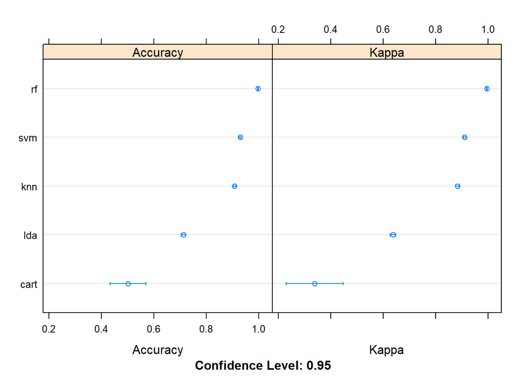

```r
dotplot(results)
```

# PRINTING BEST RESULTS

From the dotplot, random forest model yields the best results.

```r
print(fit.rf)
```

```
## Random Forest
##
## 13737 samples
##    53 predictor
##     5 classes: 'A', 'B', 'C', 'D', 'E'
##
## No pre-processing
## Resampling: Cross-Validated (10 fold)
## Summary of sample sizes: 12363, 12363, 12362, 12362, 12363, 12364, ...
## Resampling results across tuning parameters:
##
##   mtry  Accuracy   Kappa
##    2    0.9943211  0.9928164
##   27    0.9969425  0.9961327
##   53    0.9951949  0.9939222
##
## Accuracy was used to select the optimal model using the largest value.
## The final value used for the model was mtry = 27.
```

# MAKING PREDICTIONS on the test_set to get the Confusion Matrix

```r
predictions_test <- predict(fit.rf, test_set)
confusionMatrix(predictions_test, as.factor(test_set$classe))
```

```
## Confusion Matrix and Statistics
##
##           Reference
## Prediction    A    B    C    D    E
##          A 1674    1    0    0    0
##          B    0 1135    1    0    0
##          C    0    3 1025    1    1
##          D    0    0    0  963    2
##          E    0    0    0    0 1079
##
## Overall Statistics
##
##                Accuracy : 0.9985
##                  95% CI : (0.9971, 0.9993)
##     No Information Rate : 0.2845
##     P-Value [Acc > NIR] : < 2.2e-16
##
##                   Kappa : 0.9981
##
##  Mcnemar's Test P-Value : NA
##
## Statistics by Class:
##
##                      Class: A Class: B Class: C Class: D Class: E
## Sensitivity            1.0000   0.9965   0.9990   0.9990   0.9972
## Specificity            0.9998   0.9998   0.9990   0.9996   1.0000
## Pos Pred Value         0.9994   0.9991   0.9951   0.9979   1.0000
## Neg Pred Value         1.0000   0.9992   0.9998   0.9998   0.9994
## Prevalence             0.2845   0.1935   0.1743   0.1638   0.1839
## Detection Rate         0.2845   0.1929   0.1742   0.1636   0.1833
## Detection Prevalence   0.2846   0.1930   0.1750   0.1640   0.1833
## Balanced Accuracy      0.9999   0.9981   0.9990   0.9993   0.9986
```

# MAKING PREDICTIONS on the validation_set to answer the quiz

```r
predictions <- predict(fit.rf, validation)
predictions
```

```
##  [1] B A B A A E D B A A B C B A E E A B B B
## Levels: A B C D E
```